## 空間分析 第一次期中考

#### 助教 承軒 2019.03.25

## 實作主題：了解捷運站附近的人口數與各級學校分布

> > ※圖資：  
> > ＊ MRT.shp：台北市捷運站點資料（TWD97-TM2）  
> > MRT_NAME (MRT_ID)：捷運站名稱（捷運站編號）  
> > LINE：捷運站路線分類（單一路線／轉運站）  
> > ＊ TPE_LI.shp：台北市村里面資料（WGS84-經緯度）  
> > VILLAGE (V_ID)：村里（村里編號）  
> > CENSUS：人口數（單位：人）※注意資料格式  
> > ＊ SCHOOL.shp：台北市中學學校點資料（TWD97-TM2）  
> > NAME (ENG_NAME)：消防隊的單位名稱（英文名稱）  
> > TYPE：學校類別（國中／高中／高職）

> > ※座標參考系統 CRS 之 proj4 格式：  
> > [EPSG:4326] WGS84 經緯度：  
> > +proj=longlat +datum=WGS84 +no_defs +ellps=WGS84  
> > [EPSG:3826] TWD97 TM2：  
> > +proj=tmerc +lat_0=0 +lon_0=121 +k=0.9999 +x_0=250000+y_0=0 +ellps=GRS80 +units=m +no_defs

> ＊初步環境建置與讀取檔案

> ```r
> library(GISTools);library(rgdal);library(sp);library(ggplot2)
> setwd("D:/1072SA/Mid1/Mid1_Data")
> windowsFonts(JH = windowsFont("微軟正黑體"))
> MRT=readOGR(dsn = ".", layer = "MRT", encoding="unicode",verbose = F)
> TPE=readOGR(dsn = ".", layer = "TPE_LI", encoding="unicode",verbose = F)
> SCHOOL=readOGR(dsn = ".", layer = "SCHOOL", encoding="unicode",verbose = F)
> TPE=spTransform(TPE,MRT@proj4string)
> ```

> > **一、 [20%] 地圖繪製：利用ggplot套件繪製台北市人口密度與捷運站點分布**

> ```r
> TPE$CENSUS=as.numeric(as.character(TPE$CENSUS))
> TPE$AREA=poly.areas(TPE)
> TPE$DENSITY=TPE$CENSUS/TPE$AREA*10^3
> TPE.f = fortify(TPE, region="V_ID")
> TPE.f = merge(TPE.f, TPE@data, by.x = "id", by.y = "V_ID")
> ```

> 簡易版

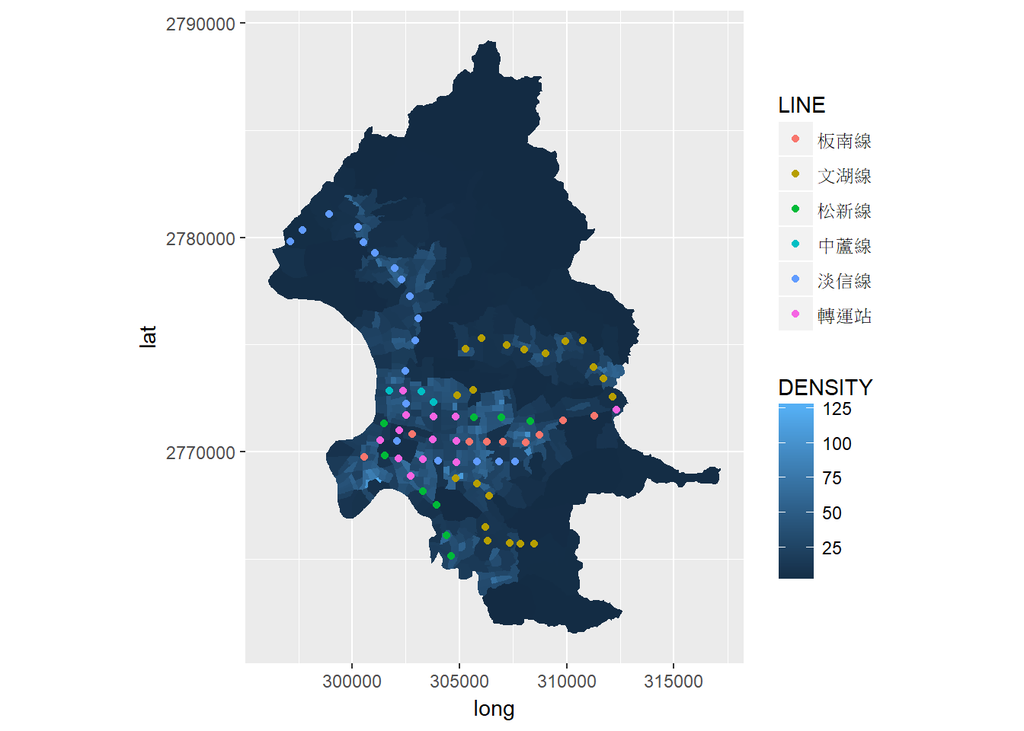

> ```r
> ggplot()+
>  geom_polygon(data =TPE.f, aes(x=long, y = lat, group = group,fill=DENSITY)) +
>  geom_point(aes(x=MRT@coords[,1],y=MRT@coords[,2],color=MRT$LINE),pch=19)+coord_fixed(1.0)+
>  scale_color_discrete("LINE",labels=c("板南線","文湖線","松新線","中蘆線","淡信線","轉運站"))
> ```

> 完整版

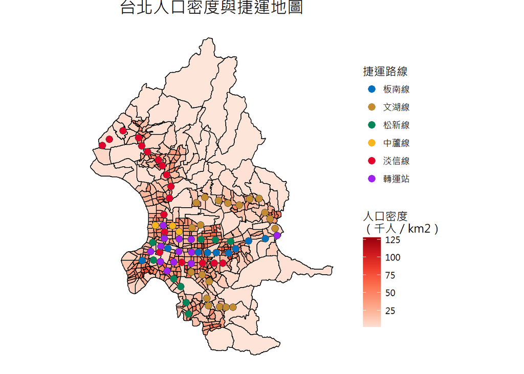

> ```r
> ggplot()+
>  geom_polygon(data =TPE.f, aes(x=long, y = lat, group = group,fill=DENSITY), color="black") +
>  scale_fill_gradientn("人口密度\n（千人／km2）",colors=brewer.pal(7,"Reds"))+
>  geom_point(aes(x=MRT@coords[,1],y=MRT@coords[,2],color=MRT$LINE),pch=19,cex=3)+coord_fixed(1.0)+
>  scale_color_manual("捷運路線",values=c("BL"="#0070bd","BR"="#c48c31","G"="#008659","O"="#f8b61c","R"="#e3002c","TRANS"="purple"),labels=c("BL"="板南線","BR"="文湖線","G"="松新線","O"="中蘆線","R"="淡信線","TRANS"="轉運站"))+
>  geom_point(aes(x=MRT@coords[,1],y=MRT@coords[,2]),color="#444444",pch=1,cex=3)+
>  scale_x_continuous(labels =NULL,name =NULL )+  scale_y_continuous(labels =NULL,name =NULL )+
>  theme_void()+labs(title ="台北人口密度與捷運地圖")+
>  theme(legend.position = "right")+theme(plot.title = element_text(size=16,hjust = 0.5))+
>  theme(text=element_text(family="JH"))
> ```

> > **二、 [50%] 資料分析：估計捷運站鄰近地區的人口數**
> > 1. [30%] 計算台北市捷運站方圓500公尺涵蓋的總人口數。

> ```r
> MRTB=gBuffer(MRT,width=500)
> Inter=gIntersection(MRTB,TPE,byid=T)
> ID=as.numeric(substring(names(Inter),8,10))
> IPOP=TPE$CENSUS[ID+1]
> IA1=poly.areas(Inter)
> IA2=TPE$AREA[ID+1]
> sum(round(IPOP*IA1/IA2))
> ```

> ```
> ## [1] 1179439
> ```

> > 2. [20%] 建立自訂函數，提供使用者設定某捷運站在特定距離方圓內涵蓋的人數。

> ```r
> #2-2
> STN_POP=function(id,dist){
>  STN=MRT[MRT$MRT_ID==id,]
>  STNB=gBuffer(STN,width=dist)
>  Inter=gIntersection(STNB,TPE,byid=T)
>  IDs=as.numeric(substring(names(Inter),8,10))+1
>  pop=TPE$CENSUS[IDs]*poly.areas(Inter)/TPE$AREA[IDs]
>  return(sum(round(pop)))
> }
> ```

> ```r
> STN_POP (38,500)
> ```

> ```
> ## [1] 6729
> ```

> ```r
> STN_POP (20,1000)
> ```

> ```
> ## [1] 102791
> ```

> ```r
> STN_POP (48,1000)
> ```

> ```
> ## [1] 93584
> ```

> ```r
> STN_POP (43,2000)
> ```

> ```
> ## [1] 359245
> ```

> > **三、 [30%] 圖表繪製：台北市國中到最近捷運站距離的累積頻率曲線**

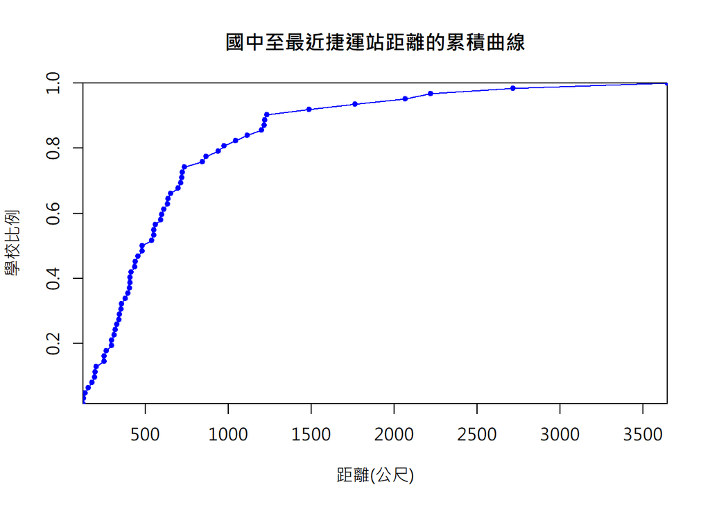

> ```r
> JH=SCHOOL[SCHOOL$TYPE=="國中",]
> MJ.d=gDistance(JH,MRT,byid=T)
> MJ.n=sort(apply(MJ.d,2,min))
> MJ.i=c(1:length(MJ.n))/length(MJ.n)
> par(family="JH")
> plot(MJ.n,MJ.i,'l',col="blue",main="國中至最近捷運站距離的累積曲線",xlab="距離(公尺)",ylab="學校比例",xaxs = "i", yaxs ="i")
> points(MJ.n,MJ.i,pch=20,col="blue")
> ```